# Scat!

Author

Sepehr Akbari

Published

September 9, 2024

# Question

Refer to the `scat` data set from the `modeldata` package. Explore this set visually for patterns and associations between variables, then write a short narrative with 1-2 conclusions. Create at least 3 clear and interesting plots which support those conclusions. You may need to do a small amount of outside reading to learn what the relevant variables are and how they might be interpreted. Such information should be included in your narrative.

Note: I recommend against using time as a variable in this assignment as it’s split between two columns

# Answer

### Loading Packages

```r
library(tidyverse)
library(modeldata)
```

### Data Exploration

```r
glimpse(scat)
```

```
Rows: 110
Columns: 19
$ Species   <fct> coyote, coyote, bobcat, coyote, coyote, coyote, bobcat, bobc…
$ Month     <fct> January, January, January, January, January, January, Januar…
$ Year      <int> 2012, 2012, 2012, 2012, 2012, 2012, 2012, 2012, 2012, 2012, …
$ Site      <fct> YOLA, YOLA, YOLA, YOLA, YOLA, YOLA, ANNU, ANNU, ANNU, ANNU, …
$ Location  <fct> edge, edge, middle, middle, edge, edge, off_edge, off_edge, …
$ Age       <int> 5, 3, 3, 5, 5, 5, 1, 3, 5, 5, 3, 1, 3, 3, 1, 5, 5, 5, 5, 3, …
$ Number    <int> 2, 2, 2, 2, 4, 3, 5, 7, 2, 1, 1, 1, 1, 1, 1, 1, 7, 6, 4, 3, …
$ Length    <dbl> 9.5, 14.0, 9.0, 8.5, 8.0, 9.0, 6.0, 5.5, 11.0, 20.5, 8.0, 8.…
$ Diameter  <dbl> 25.7, 25.4, 18.8, 18.1, 20.7, 21.2, 15.7, 21.9, 17.5, 18.0, …
$ Taper     <dbl> 41.9, 37.1, 16.5, 24.7, 20.1, 28.5, 8.2, 19.3, 29.1, 21.4, N…
$ TI        <dbl> 1.63, 1.46, 0.88, 1.36, 0.97, 1.34, 0.52, 0.88, 1.66, 1.19, …
$ Mass      <dbl> 15.89, 17.61, 8.40, 7.40, 25.45, 14.14, 14.82, 26.41, 16.24,…
$ d13C      <dbl> -26.85, -29.62, -28.73, -20.07, -23.24, -29.00, -28.06, -27.…
$ d15N      <dbl> 6.94, 9.87, 8.52, 5.79, 7.01, 8.28, 4.20, 3.89, 7.34, 6.06, …
$ CN        <dbl> 8.50, 11.30, 8.10, 11.50, 10.60, 9.00, 5.40, 5.60, 5.80, 7.7…
$ ropey     <int> 0, 0, 1, 1, 0, 1, 1, 0, 0, 1, 0, 1, 0, 0, 0, 1, 1, 1, 1, 1, …
$ segmented <int> 0, 0, 1, 0, 1, 0, 1, 1, 1, 1, 0, 0, 0, 0, 0, 1, 1, 1, 0, 1, …
$ flat      <int> 0, 0, 0, 0, 0, 0, 0, 0, 0, 0, 1, 0, 1, 1, 1, 0, 0, 0, 0, 0, …
$ scrape    <int> 0, 0, 1, 0, 0, 0, 1, 0, 0, 0, 0, 0, 0, 0, 0, 0, 0, 0, 0, 0, …
```

The `scat` dataset contains measurements and characteristics of scat samples collected from various species, including details like species, location found, physical dimensions, and isotope ratios, allowing for ecological and dietary analysis of the animals. This kind of data set can be useful to make data supported assumptions, or even conclusions, about different scat species.

### Conclusion 1

One of the interesting data collected in this data set is delta-C 13 measurement for Carbon 12 and 13 isotopes’ spread ratio, which can give us insight on the scat’s dietary habits.

We can try and see if there is any relation between the scats’ locations and their diet. To do so, let’s compare `d13C` and `Location` by species. As `Mass` also has a significant affect on a scat’s diet, we’ll include that as well.

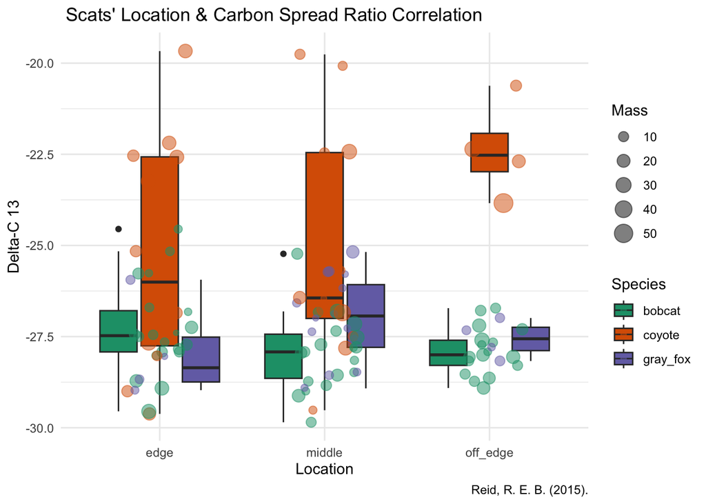

```r
ggplot(
  scat,
  aes(
    x = Location,
    y = d13C,
    fill = Species
  )
) +
  geom_boxplot() +
  geom_jitter(
    aes(color = Species, size = Mass),
    width = 0.2, alpha = 0.5
  ) +
  labs(
    title = " Scats' Location & Carbon Spread Ratio Correlation",
    x = "Location",
    y = "Delta-C 13",
    size = "Mass",
    caption = "Reid, R. E. B. (2015)."
  ) +
  scale_color_brewer(palette = 'Dark2') +
  scale_fill_brewer(palette = 'Dark2') +
  theme_minimal()
```

From this data we can see that:

**Summary**

Coyotes,seem to have a more varied diet, especially in the middle of the habitat. In contrast, bobcats and gray foxes exhibit more specialized diets with lower d13C values. In the off_edge locations, coyotes’ diet is completely different from the other species.

The size of the scat seems to correlate with species dietary behavior, which has led to a smaller size gray_fox scat sample.

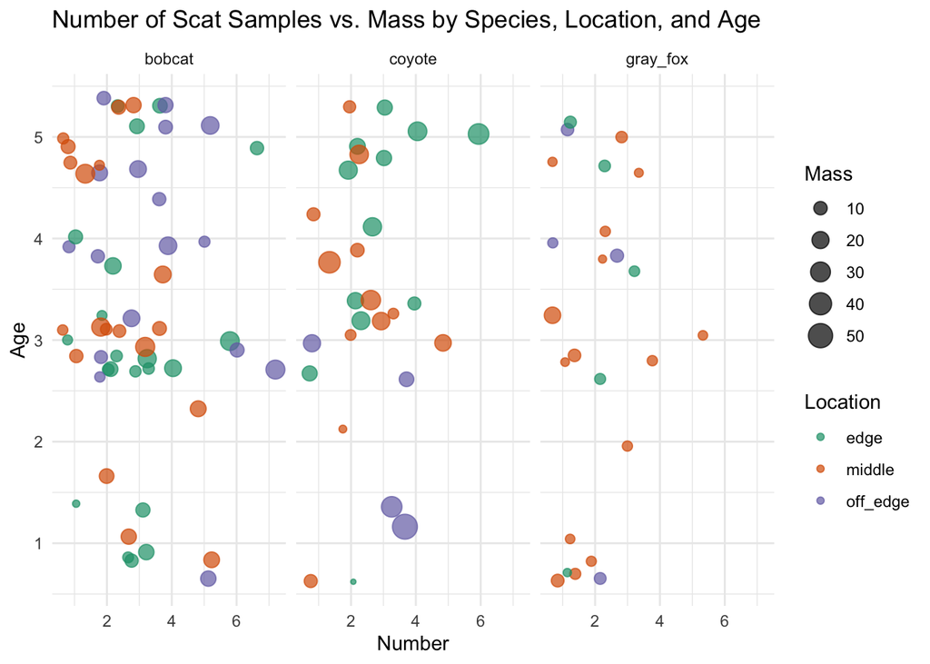

```r
ggplot(
  scat,
  aes(
    x = Number,
    y = Age,
    color = Location,
    size = Mass  # Map point size to the Age variable
  )
) +
  geom_jitter(alpha = 0.7) +  # Alpha transparency to avoid overlap
  facet_wrap(~ Species) +  # Separate facet for each species
  labs(
    title = "Number of Scat Samples vs. Mass by Species, Location, and Age"
  ) +
  theme_minimal() +
  scale_color_brewer(palette = "Dark2") +
  scale_fill_brewer(palette = "Dark2") +
  theme(legend.position = "right")
```